# Домашнее задание по автоматизации обработки данных

Authors

[Юлия Ченгаева](https://github.com/ichengaeva)

[Алена Вейс](https://github.com/veysao)

[Наталья Кичигина](https://github.com/NataKich)

[Амир Сафин](https://github.com/lechiticho)

**Создайте ветку**, заполните сведения о себе выше и **сделайте Pull Request**.

**Вариант 4**  
* **Группы лечения (`ARM`):** Placebo, Xanomeline Low Dose  
* **Лабораторные показатели (`LBTESTCD`):** HGB, PLAT  
* **Визит для веса (`VISIT`):** WEEK 4

## 1. Импорт и очистка данных

Каждый выполняет в своей ветке.

### 1.1. Пациенты

В файле `data/dm.csv` содержатся демографические данные участников исследования. Вам понадобятся следующие столбцы:

- `USUBJID` — уникальный идентификатор участника
- `AGE` — возраст на момент скрининга, полных лет
- `SEX` — пол участника
- `ARM` — группа лечения
- `RFSTDTC` — дата первого приёма препарата
1. Импортируйте данные.
2. Какой формат у этих данных: длинный или широкий? Объясните ответ. Формат данных: Исходный датасет dm.csv представлен в широком формате (wide format), так как каждому участнику исследования соответствует ровно одна строка, а его параметры (возраст, пол, группа лечения) расположенны в отдельных столбцах.
3. Оставьте только нужные столбцы и переименуйте `USUBJID` в `ID`.

```r
library(flextable)

# 1. Импорт данных
dm_raw <- read_csv("dm.csv", show_col_types = FALSE)

# 3. Отбор нужных столбцов и переименование USUBJID в ID
dm <- dm_raw |>
  filter(ARM %in% c("Placebo", "Xanomeline Low Dose")) |>
  select(
    ID = USUBJID,
    AGE,
    SEX,
    ARM,
    RFSTDTC
  )

# Вывод первых строк
dm |>
  head(10) |>
  flextable() |>
  autofit()
```

| ID | AGE | SEX | ARM | RFSTDTC |
| --- | --- | --- | --- | --- |
| 01-701-1015 | 63 | F | Placebo | 2014-01-02 |
| 01-701-1023 | 64 | M | Placebo | 2012-08-05 |
| 01-701-1033 | 74 | M | Xanomeline Low Dose | 2014-03-18 |
| 01-701-1047 | 85 | F | Placebo | 2013-02-12 |
| 01-701-1097 | 68 | M | Xanomeline Low Dose | 2014-01-01 |
| 01-701-1111 | 81 | F | Xanomeline Low Dose | 2012-09-07 |
| 01-701-1115 | 84 | M | Xanomeline Low Dose | 2012-11-30 |
| 01-701-1118 | 52 | M | Placebo | 2014-03-12 |
| 01-701-1130 | 84 | M | Placebo | 2014-02-15 |
| 01-701-1153 | 79 | F | Placebo | 2013-09-23 |

4. Проверьте, что каждому участнику соответствует ровно одна строка. Если идентификатор участника встречается несколько раз, выведите все такие строки. Проверка пройдена: все ID участников уникальны.

```r
# 4. Проверка: каждому участнику соответствует ровно одна строка
duplicates <- dm |>
  filter(duplicated(ID) | duplicated(ID, fromLast = TRUE))

if (nrow(duplicates) > 0) {
  print(duplicates)
  stop("Ошибка: обнаружены дублирующиеся идентификаторы участников!")
} else {
  message("Проверка пройдена: все ID участников уникальны.")
}
```

5. Выведите общее количество людей, оцененных для включения в исследование.

```r
total_screened <- nrow(dm_raw)
total_screened
```

```
[1] 306
```

6. Какой процент не прошел скрининг?

```r
randomized_total <- dm_raw |>
  filter(!is.na(ARM) & ARM != "Screen Failure") |>
  nrow()

screen_failures <- total_screened - randomized_total
pct_failed <- (screen_failures / total_screened) * 100

cat("Всего оцененных участников:", total_screened, "\n")
```

```
Всего оцененных участников: 306
```

```r
cat("Не прошли скрининг:", screen_failures, sprintf("(%.2f%%)\n\n", pct_failed))
```

```
Не прошли скрининг: 52 (16.99%)
```

7. Оставьте участников с группами лечения из вашего варианта. Преобразуйте столбец `ARM` в фактор и выведите число участников в каждой группе.

```r
unique(dm_raw$ARM)
```

```
[1] "Placebo"              "Xanomeline High Dose" "Xanomeline Low Dose"
[4] "Screen Failure"
```

```r
dm <- dm |>
  filter(ARM %in% c("Placebo", "Xanomeline Low Dose")) |>
  mutate(ARM = as.factor(ARM))
table(dm$ARM)
```

```
            Placebo Xanomeline Low Dose
                 86                  84
```

8. Сохраните финальный датафрейм в переменную `dm`.

```r
library(DT)

dm |>
  datatable(
    options = list(
      scrollY = "300px", # Высота окна с вертикальной прокруткой
      paging = FALSE, # Вывод всех строк списком без разбивки по страницам
      searching = FALSE, # Убрать строку поиска
      info = FALSE
    ),
    rownames = FALSE
  )
```

| ID | AGE | SEX | ARM | RFSTDTC |
| --- | --- | --- | --- | --- |
| 01-701-1015 | 63 | F | Placebo | 2014-01-02 |
| 01-701-1023 | 64 | M | Placebo | 2012-08-05 |
| 01-701-1033 | 74 | M | Xanomeline Low Dose | 2014-03-18 |
| 01-701-1047 | 85 | F | Placebo | 2013-02-12 |
| 01-701-1097 | 68 | M | Xanomeline Low Dose | 2014-01-01 |
| 01-701-1111 | 81 | F | Xanomeline Low Dose | 2012-09-07 |
| 01-701-1115 | 84 | M | Xanomeline Low Dose | 2012-11-30 |
| 01-701-1118 | 52 | M | Placebo | 2014-03-12 |
| 01-701-1130 | 84 | M | Placebo | 2014-02-15 |
| 01-701-1153 | 79 | F | Placebo | 2013-09-23 |

[output cut: 160 more lines]

### 1.2. Лабораторные измерения

Файл `data/lb.csv` содержит результаты лабораторных измерений участников исследования. Вам понадобятся следующие столбцы:

- `USUBJID` — уникальный идентификатор участника
- `LBTESTCD` / `LBTEST` — код / название лабораторного теста
- `LBSTRESN` — числовой результат измерения
- `VISIT` — визит измерения
- `LBDTC` / `LBDY` — дата / день измерения
1. Импортируйте данные.
2. Какой формат у этих данных: длинный или широкий? Объясните ответ. Это длинные данные, т.к. на одного участника приходится несколько строк. Какое минимальное и максимальное число строк на одного пациента? Минимальное - 9, максимальное - 58
3. На каких визитах выполняли измерения и какие лабораторные показатели измеряли? Визиты: WEEK 4, WEEK 6, WEEK 8, WEEK 12, SCREENING 1, WEEK 2, BASELINE  
   Лабораторные показатели: Basophils, Eosinophils, Hemoglobin, Lymphocytes, Monocytes, Platelet, Erythrocytes, Thyrotropin, Vitamin B12, Leukocytes Отдельно выведите или подчеркните визиты, на которых измеряли витамин B12.

```r
library(tidyverse)
data <- read_csv("lb.csv")

data <- data |>
  semi_join(dm, by = c("USUBJID" = "ID"))

rows <- data |>
  count(USUBJID)

rows |>
  summarise(
    "Минимальное количество строк" = min(n),
    "Максимальное количество строк" = max(n)
  ) |>
  flextable() |>
  set_caption("Количество строк в датасете")
```

| Минимальное количество строк | Максимальное количество строк |
| --- | --- |
| 9 | 58 |

```r
visits <- data |>
  distinct(VISIT)
flextable(visits) |>
  set_header_labels(VISIT = "Визиты") |>
  autofit()
```

| Визиты |
| --- |
| WEEK 4 |
| WEEK 6 |
| WEEK 8 |
| WEEK 12 |
| SCREENING 1 |
| WEEK 2 |
| BASELINE |

```r
tests <- data |>
  distinct(LBTEST)
flextable(tests) |>
  set_header_labels(LBTEST = "Виды лабораторных исследований") |>
  autofit()
```

| Виды лабораторных исследований |
| --- |
| Basophils |
| Eosinophils |
| Hemoglobin |
| Lymphocytes |
| Monocytes |
| Platelet |
| Erythrocytes |
| Thyrotropin |
| Vitamin B12 |
| Leukocytes |

```r
vit <- data |>
  filter(LBTEST == "Vitamin B12")
datatable(
  vit,
  options = list(
    scrollY = "400px",
    scrollX = TRUE,
    paging = FALSE,
    searching = FALSE,
    info = FALSE
  ),
  rownames = FALSE
)
```

| USUBJID | LBTESTCD | LBTEST | LBCAT | LBORRES | LBSTRESN | LBSTRESU | LBSTNRLO | LBSTNRHI | LBNRIND | VISIT | LBDTC | LBDY |
| --- | --- | --- | --- | --- | --- | --- | --- | --- | --- | --- | --- | --- |
| 01-701-1015 | VITB12 | Vitamin B12 | OTHER | 399 | 294.3822 | pmol/L | 148 | 664 | NORMAL | SCREENING 1 | 2013-12-26T14:45:00Z | -7 |
| 01-701-1023 | VITB12 | Vitamin B12 | OTHER | 553 | 408.0034 | pmol/L | 148 | 664 | NORMAL | SCREENING 1 | 2012-07-22T12:13:00Z | -14 |
| 01-701-1033 | VITB12 | Vitamin B12 | OTHER | 503 | 371.1134 | pmol/L | 148 | 664 | NORMAL | SCREENING 1 | 2014-03-10T12:31:00Z | -8 |
| 01-701-1047 | VITB12 | Vitamin B12 | OTHER | 585 | 431.613 | pmol/L | 148 | 664 | NORMAL | SCREENING 1 | 2013-01-22T14:36:00Z | -21 |
| 01-701-1097 | VITB12 | Vitamin B12 | OTHER | 411 | 303.2358 | pmol/L | 148 | 664 | NORMAL | SCREENING 1 | 2013-12-23T12:30:00Z | -9 |
| 01-701-1111 | VITB12 | Vitamin B12 | OTHER | 527 | 388.8206 | pmol/L | 148 | 664 | NORMAL | SCREENING 1 | 2012-08-25T15:25:00Z | -13 |
| 01-701-1115 | VITB12 | Vitamin B12 | OTHER | 641 | 472.9298 | pmol/L | 148 | 664 | NORMAL | SCREENING 1 | 2012-11-23T11:20:00Z | -7 |
| 01-701-1118 | VITB12 | Vitamin B12 | OTHER | 289 | 213.2242 | pmol/L | 148 | 664 | NORMAL | SCREENING 1 | 2014-02-27T10:32:00Z | -13 |
| 01-701-1130 | VITB12 | Vitamin B12 | OTHER | 355 | 261.919 | pmol/L | 148 | 664 | NORMAL | SCREENING 1 | 2014-02-09T12:01:00Z | -6 |
| 01-701-1153 | VITB12 | Vitamin B12 | OTHER | 345 | 254.541 | pmol/L | 148 | 664 | NORMAL | SCREENING 1 | 2013-09-06T14:50:00Z | -17 |

[output cut: 156 more lines]

```r
# select, rename
# distinct, count
```

4. Оставьте только два лабораторных показателя своей команды, измеренных на визите `SCREENING 1`.
5. После фильтрации выведите число измерений каждого показателя.

```r
scr1 <- data |>
  filter(
    (LBTESTCD == "HGB" | LBTESTCD == "PLAT") &
      VISIT == "SCREENING 1"
  ) |>
  count(LBTESTCD)
flextable(scr1) |>
  set_header_labels(
    LBTESTCD = "Показатель",
    n = "Количество измерений"
  ) |>
  autofit()
```

| Показатель | Количество измерений |
| --- | --- |
| HGB | 166 |
| PLAT | 163 |

6. Переведите данные в широкий формат и сохраните в переменную `lb_wide`. В датафрейме должна быть одна строка на одного участника и по крайней мере два столбца с показателями вашей команды. Идентификатор участника должен находиться в столбце с названием `ID`.

```r
lb_wide <- data |>
  filter(
    LBTESTCD %in% c("HGB", "PLAT"),
    VISIT == "SCREENING 1"
  ) |>
  select(
    ID = USUBJID,
    LBTESTCD,
    LBSTRESN
  ) |>
  pivot_wider(
    names_from = LBTESTCD,
    values_from = LBSTRESN
  )
datatable(
  lb_wide,
  options = list(
    scrollY = "400px",
    scrollX = TRUE,
    paging = FALSE,
    searching = FALSE,
    info = FALSE
  ),
  rownames = FALSE
)
```

| ID | HGB | PLAT |
| --- | --- | --- |
| 01-701-1015 | 8.87458 | 266 |
| 01-701-1023 | 10.05372 | 217 |
| 01-701-1033 | 9.99166 | 190 |
| 01-701-1047 | 9.49518 | 224 |
| 01-701-1097 | 9.37106 | 270 |
| 01-701-1111 | 7.4472 | 255 |
| 01-701-1115 | 9.24694 | 150 |
| 01-701-1118 | 9.68136 | 268 |
| 01-701-1130 | 7.50926 | 196 |
| 01-701-1153 | 8.00574 | 293 |

[output cut: 156 more lines]

7. Вернитесь к пункту 1, где вы импортировали данные. Оставьте только участников своей команды и выполните код следующих пунктов заново. Используйте датафрейм `dm`, созданный координатором в разделе 1.1 выше и функции `left_join / semi_join / filter`.
8. Проверьте, что `lb_wide` содержит ровно одну строку на одного участника.

```r
if (any(table(lb_wide$ID) != 1)) {
  stop("lb_wide содержит не одну строку на участника")
}
```

9. Дополнительное задание: вычислите `LBDY` самостоятельно (от даты первого приема препарата) и проверьте совпадает ли с оригинальным столбцом

```r
data_lbdy <- data |>
  filter(VISIT != "SCREENING 1")

LBDY1 <- data_lbdy |>
  left_join(
    dm |> select(ID, RFSTDTC),
    by = c("USUBJID" = "ID")
  )

LBDY1 <- LBDY1 |>
  mutate(
    LBDY_calc = as.integer(as.Date(LBDTC) - as.Date(RFSTDTC)) + 1
  )

check_LBDY <- LBDY1 |>
  summarise(
    `Всего записей` = n(),
    `Совпадений LBDY` = sum(LBDY_calc == LBDY, na.rm = TRUE),
    `Расхождений` = sum(LBDY_calc != LBDY | is.na(LBDY_calc) != is.na(LBDY))
  ) |>
  flextable() |>
  autofit()

check_LBDY
```

| Всего записей | Совпадений LBDY | Расхождений |
| --- | --- | --- |
| 5,547 | 5,547 | 0 |

### 1.3. Витальные показатели

Файл `data/vs.xlsx` содержит результаты измерений витальных показателей участников исследования, включая рост и вес. Вам понадобятся следующие столбцы:

- `USUBJID` — уникальный идентификатор участника
- `VSTESTCD` / `VSTEST` — код / название измеряемого показателя
- `VSSTRESN` — числовой результат измерения
- `VISIT` — визит исследования
- `VSDTC` / `VSDY` — дата / день визита
1. Импортируйте данные.
2. Какой формат у этих данных: длинный или широкий? Объясните ответ.

2.1. Формат данных длинный, так как в столбце ID число уникальных ID 254, а количество всех ID 15764, при широком формате количество строк равнялось бы количеству участников. В столбце VSTESTCD также имеется несколько видов измерения: DIABP, HEIGHT, PULSE, SYSBP, WEIGHT. При широком формате такие измерения должны находиться в разных столбцах. Нет интересующих измерений HEIGHT и вес WEIGHT в отдельных столбах.

2.2. Какое минимальное и максимальное число строк на одного участника?

Минимальное количество строк на одного участника - 21  
Максимальное количество строк - 71

3. На каких визитах измеряли рост (`HEIGHT`) и вес (`WEIGHT`)?

Рост измеряли на визите SCREENING 1  
Вес измеряли на визитах SCREENING 1, BASELINE, WEEK 2, WEEK 4, WEEK 6, WEEK 8, WEEK 12.

4. Импорт данных и очистка.

```r
vs <- readxl::read_excel("vs.xlsx") |>
  select(USUBJID, VSTESTCD, VSTEST, VSSTRESN, VISIT, VSDTC, VSDY) |>
  rename(ID = USUBJID)
# Вывод первых строк в стиле flextable
vs |>
  head(10) |>
  flextable() |>
  autofit()
```

| ID | VSTESTCD | VSTEST | VSSTRESN | VISIT | VSDTC | VSDY |
| --- | --- | --- | --- | --- | --- | --- |
| 01-701-1015 | DIABP | Diastolic Blood Pressure | 64 | SCREENING 1 | 2013-12-26 00:00:00 | -7 |
| 01-701-1015 | DIABP | Diastolic Blood Pressure | 83 | SCREENING 1 | 2013-12-26 00:00:00 | -7 |
| 01-701-1015 | DIABP | Diastolic Blood Pressure | 57 | SCREENING 1 | 2013-12-26 00:00:00 | -7 |
| 01-701-1015 | DIABP | Diastolic Blood Pressure | 56 | BASELINE | 2014-01-02 00:00:00 | 1 |
| 01-701-1015 | DIABP | Diastolic Blood Pressure | 51 | BASELINE | 2014-01-02 00:00:00 | 1 |
| 01-701-1015 | DIABP | Diastolic Blood Pressure | 61 | BASELINE | 2014-01-02 00:00:00 | 1 |
| 01-701-1015 | DIABP | Diastolic Blood Pressure | 56 | WEEK 2 | 2014-01-16 00:00:00 | 15 |
| 01-701-1015 | DIABP | Diastolic Blood Pressure | 50 | WEEK 2 | 2014-01-16 00:00:00 | 15 |
| 01-701-1015 | DIABP | Diastolic Blood Pressure | 54 | WEEK 2 | 2014-01-16 00:00:00 | 15 |
| 01-701-1015 | DIABP | Diastolic Blood Pressure | 64 | WEEK 4 | 2014-01-30 00:00:00 | 29 |

4.1 Какое минимальное и максимальное число строк на одного участника?

```r
vs |>
  count(ID) |>
  summarise(
    `Минимальное число строк` = min(n),
    `Максимальное число строк` = max(n)
  ) |>
  flextable() |>
  autofit()
```

| Минимальное число строк | Максимальное число строк |
| --- | --- |
| 21 | 71 |

4.2 На каких визитах измеряли рост (HEIGHT) и вес (WEIGHT)?

```r
vs |>
  filter(VSTESTCD %in% c("HEIGHT", "WEIGHT")) |>
  distinct(VSTESTCD, VISIT) |>
  rename(`Показатель` = VSTESTCD, `Визит` = VISIT) |>
  flextable() |>
  autofit()
```

| Показатель | Визит |
| --- | --- |
| HEIGHT | SCREENING 1 |
| WEIGHT | SCREENING 1 |
| WEIGHT | BASELINE |
| WEIGHT | WEEK 2 |
| WEIGHT | WEEK 4 |
| WEIGHT | WEEK 6 |
| WEIGHT | WEEK 8 |
| WEIGHT | WEEK 12 |

4.3 Оставьте измерения роста и веса на визите `SCREENING 1`, а также измерения веса на визите вашей команды.

```r
vs_filtered <- vs |>
  filter(
    (VSTESTCD == "HEIGHT" & VISIT == "SCREENING 1") |
      (VSTESTCD == "WEIGHT" & VISIT == "SCREENING 1") |
      (VSTESTCD == "WEIGHT" & VISIT == "WEEK 4")
  )

# Вывод отфильтрованных данных в виде таблицы
vs_filtered |>
  head(10) |>
  flextable() |>
  autofit()
```

| ID | VSTESTCD | VSTEST | VSSTRESN | VISIT | VSDTC | VSDY |
| --- | --- | --- | --- | --- | --- | --- |
| 01-701-1015 | HEIGHT | Height | 147.32 | SCREENING 1 | 2013-12-26 00:00:00 | -7 |
| 01-701-1015 | WEIGHT | Weight | 53.98 | SCREENING 1 | 2013-12-26 00:00:00 | -7 |
| 01-701-1015 | WEIGHT | Weight | 53.98 | WEEK 4 | 2014-01-30 00:00:00 | 29 |
| 01-701-1023 | HEIGHT | Height | 162.56 | SCREENING 1 | 2012-07-22 00:00:00 | -14 |
| 01-701-1023 | WEIGHT | Weight | 78.47 | SCREENING 1 | 2012-07-22 00:00:00 | -14 |
| 01-701-1023 | WEIGHT | Weight | 80.29 | WEEK 4 | 2012-09-02 00:00:00 | 29 |
| 01-701-1028 | HEIGHT | Height | 177.80 | SCREENING 1 | 2013-07-11 00:00:00 | -8 |
| 01-701-1028 | WEIGHT | Weight | 98.88 | SCREENING 1 | 2013-07-11 00:00:00 | -8 |
| 01-701-1028 | WEIGHT | Weight | 98.88 | WEEK 4 | 2013-08-14 00:00:00 | 27 |
| 01-701-1033 | HEIGHT | Height | 175.26 | SCREENING 1 | 2014-03-10 00:00:00 | -8 |

5. Переведите данные в широкий формат и сохраните в переменной `vs_wide`. В датафрейме должны быть столбцы для всех трёх отобранных измерений. Подсказка: значение, которое вы передаёте в `names_from`, должно быть уникальным для каждого участника. Проверьте это до вызова `pivot_wider()`. Идентификатор участника должен находиться в столбце с названием `ID`.

```r
# Проверка уникальности (без вывода служебного tibble)
stopifnot(nrow(vs_filtered |> count(ID, VSTESTCD, VISIT) |> filter(n > 1)) == 0)

# Создание составной колонки name и перевод в широкий формат
vs_wide <- vs_filtered |>
  mutate(name = str_c(VSTESTCD, VISIT, sep = "_")) |>
  pivot_wider(id_cols = ID, names_from = name, values_from = VSSTRESN)

# Вывод результата
vs_wide |>
  head(10) |>
  flextable() |>
  autofit()
```

| ID | HEIGHT_SCREENING 1 | WEIGHT_SCREENING 1 | WEIGHT_WEEK 4 |
| --- | --- | --- | --- |
| 01-701-1015 | 147.32 | 53.98 | 53.98 |
| 01-701-1023 | 162.56 | 78.47 | 80.29 |
| 01-701-1028 | 177.80 | 98.88 | 98.88 |
| 01-701-1033 | 175.26 | 88.45 | 88.45 |
| 01-701-1034 | 154.94 | 63.50 | 63.96 |
| 01-701-1047 | 148.59 | 66.23 | 67.59 |
| 01-701-1097 | 168.91 | 78.02 | 79.38 |
| 01-701-1111 | 158.24 | 60.33 |  |
| 01-701-1115 | 181.61 | 78.70 | 78.47 |
| 01-701-1118 | 180.34 | 71.67 | 71.22 |

7. Вернитесь к пункту 1, где вы импортировали данные. Оставьте только участников своей команды и выполните код следующих пунктов заново. Используйте датафрейм `dm`, созданный координатором в разделе 1.1 выше и функции `left_join / semi_join / filter`.
8. Проверьте, что `vs_wide` содержит ровно одну строку на участника.

```r
# Фильтрация участников команды и нужных измерений
vs_my_team <- vs |> semi_join(dm, by = "ID")

vs_filtered_team <- vs_my_team |>
  filter(
    (VSTESTCD == "HEIGHT" & VISIT == "SCREENING 1") |
      (VSTESTCD == "WEIGHT" & VISIT == "SCREENING 1") |
      (VSTESTCD == "WEIGHT" & VISIT == "WEEK 4")
  )

# Перевод в широкий формат
vs_wide_team <- vs_filtered_team |>
  mutate(name = str_c(VSTESTCD, VISIT, sep = "_")) |>
  pivot_wider(id_cols = ID, names_from = name, values_from = VSSTRESN)

# Проверка уникальности: ровно одна строка на участника
stopifnot(nrow(vs_wide_team) == dplyr::n_distinct(vs_wide_team$ID))

# Вывод итоговой таблицы
vs_wide_team |>
  DT::datatable(
    options = list(
      pageLength = 10, # Показывать по 10 строк
      scrollX = TRUE, # Включить горизонтальную прокрутку
      autoWidth = TRUE
    ),
    filter = "top" # Добавить поля поиска/фильтрации над каждым столбцом
  )
```

|  | ID | HEIGHT_SCREENING 1 | WEIGHT_SCREENING 1 | WEIGHT_WEEK 4 |
| --- | --- | --- | --- | --- |
| 1 | 01-701-1015 | 147.32 | 53.98 | 53.98 |
| 2 | 01-701-1023 | 162.56 | 78.47 | 80.29 |
| 3 | 01-701-1033 | 175.26 | 88.45 | 88.45 |
| 4 | 01-701-1047 | 148.59 | 66.23 | 67.59 |
| 5 | 01-701-1097 | 168.91 | 78.02 | 79.38 |
| 6 | 01-701-1111 | 158.24 | 60.33 |  |
| 7 | 01-701-1115 | 181.61 | 78.7 | 78.47 |
| 8 | 01-701-1118 | 180.34 | 71.67 | 71.22 |
| 9 | 01-701-1130 | 169.67 | 79.38 | 78.02 |
| 10 | 01-701-1153 | 156.21 | 58.06 | 56.7 |

[output cut: 160 more lines]

9. Дополнительное задание: вычислите `VSDY` самостоятельно (от даты первого приема препарата) и проверьте совпадает ли с оригинальным столбцом

```r
# Вычисление VSDY вручную и проверка с оригинальным столбцом
vs_calc <- vs_my_team |>
  left_join(dm |> select(ID, RFSTDTC), by = "ID") |>
  mutate(
    # Приводим к формату Date для корректного вычитания
    date_visit = as.Date(VSDTC),
    date_first_dose = as.Date(RFSTDTC),
    diff_days = as.numeric(date_visit - date_first_dose),

    # Правило CDISC SDTM (день 0 отсутствует)
    vsdy_calc = if_else(diff_days >= 0, diff_days + 1, diff_days)
  )

# Проверка: совпадают ли расчётный VSDY и оригинальный VSDY
check_vsdy <- vs_calc |>
  summarise(
    `Всего записей` = n(),
    `Совпадений VSDY` = sum(vsdy_calc == VSDY, na.rm = TRUE),
    `Расхождений` = sum(vsdy_calc != VSDY | is.na(vsdy_calc) != is.na(VSDY))
  ) |>
  flextable() |>
  autofit()

check_vsdy
```

| Всего записей | Совпадений VSDY | Расхождений |
| --- | --- | --- |
| 10,726 | 10,726 | 0 |

### 1.4. Генотип APOE

Файл `data/gf.csv` содержит результаты генотипирования участников исследования. Вам понадобятся следующие столбцы:

- `USUBJID` — уникальный идентификатор участника
- `GFORRES` — выявленный генотип
- `GFSYM` — символ гена
- `GFPVRID` — идентификатор генетического варианта
- `VISIT` — визит исследования
- `GFDTC` / `GFDY` — дата / день генотипировани
1. Импортируйте данные.
2. Какой формат у этих данных: длинный или широкий? Объясните ответ.
- У этих данных длинный формат, так как на одного пациента приходится несколько строк Какое минимальное и максимальное число строк на одного участника?
- 12 строк на каждого участника (согласно команде summarise).

```r
gf <- read_csv('gf.csv', show_col_types = FALSE) |>
  semi_join(dm, by = c("USUBJID" = "ID")) |>
  rename(ID = USUBJID)
summary <- gf |>
  select(ID) |>
  count(ID) |>
  summarise(min_rows = min(n), max_rows = max(n))
summary
```

| min_rows | max_rows |
| --- | --- |
| 12 | 12 |

3. Оставьте только ген `APOE` и варианты с идентификаторами `rs429358` и `rs7412`.

```r
gf_filter <- gf |>
  filter(GFSYM == "APOE" & GFPVRID %in% c("rs429358", "rs7412"))
```

4. По таблице ниже определите генотип APOE для каждого участника. Для комбинации, которой нет в таблице, присвойте значение `NA`.

| rs429358 | rs7412 | Генотип APOE |
| --- | --- | --- |
| T/T | T/T | ε2/ε2 |
| T/T | C/T | ε2/ε3 |
| T/C | C/T | ε2/ε4 |
| T/T | C/C | ε3/ε3 |
| T/C | C/C | ε3/ε4 |
| C/C | C/C | ε4/ε4 |

```r
# Перевод в широкий формат и определение генотипа
gf_apoe_wide <- gf_filter |>
  select(ID, GFPVRID, GFORRES) |>
  pivot_wider(names_from = GFPVRID, values_from = GFORRES) |>
  mutate(
    gf_genotype_apoe = case_when(
      rs429358 == "T/T" & rs7412 == "T/T" ~ "ε2/ε2",
      rs429358 == "T/T" & rs7412 == "C/T" ~ "ε2/ε3",
      rs429358 == "T/C" & rs7412 == "C/T" ~ "ε2/ε4",
      rs429358 == "T/T" & rs7412 == "C/C" ~ "ε3/ε3",
      rs429358 == "T/C" & rs7412 == "C/C" ~ "ε3/ε4",
      rs429358 == "C/C" & rs7412 == "C/C" ~ "ε4/ε4",
      TRUE ~ NA_character_
    )
  )
```

5. Выведите число участников с каждым генотипом APOE.

```r
gf_apoe_wide |>
  count(gf_genotype_apoe, name = "Количество") |>
  rename(`Генотип APOE` = gf_genotype_apoe) |>
  flextable() |>
  autofit()
```

| Генотип APOE | Количество |
| --- | --- |
| ε2/ε3 | 21 |
| ε2/ε4 | 9 |
| ε3/ε3 | 68 |
| ε3/ε4 | 69 |
| ε4/ε4 | 3 |

6. Сохраните итоговый датафрейм в переменную `gf_wide`. Идентификатор участника должен находиться в столбце `ID`.

```r
gf_wide <- gf_apoe_wide |>
  select(ID, gf_genotype_apoe)
```

7. Вернитесь к пункту 1, где вы импортировали данные. Оставьте только участников своей команды и выполните код следующих пунктов заново. Используйте датафрейм `dm`, созданный координатором в разделе 1.1 выше и функции `left_join / semi_join / filter`.

```r
gf <- read_csv('gf.csv', show_col_types = FALSE) |>
  semi_join(dm, by = c("USUBJID" = "ID")) |>
  rename(ID = USUBJID)
summary <- gf |>
  select(ID) |>
  count(ID) |>
  summarise(min_rows = min(n), max_rows = max(n))
gf_filter <- gf |>
  filter(GFSYM == "APOE" & GFPVRID %in% c("rs429358", "rs7412"))
gf_apoe_wide <- gf_filter |>
  select(ID, GFPVRID, GFORRES) |>
  pivot_wider(names_from = GFPVRID, values_from = GFORRES) |>
  mutate(
    gf_genotype_apoe = case_when(
      rs429358 == "T/T" & rs7412 == "T/T" ~ "ε2/ε2",
      rs429358 == "T/T" & rs7412 == "C/T" ~ "ε2/ε3",
      rs429358 == "T/C" & rs7412 == "C/T" ~ "ε2/ε4",
      rs429358 == "T/T" & rs7412 == "C/C" ~ "ε3/ε3",
      rs429358 == "T/C" & rs7412 == "C/C" ~ "ε3/ε4",
      rs429358 == "C/C" & rs7412 == "C/C" ~ "ε4/ε4",
      TRUE ~ NA_character_
    )
  )
gf_apoe_wide |>
  count(gf_genotype_apoe, name = "Количество") |>
  rename(`Генотип APOE` = gf_genotype_apoe) |>
  flextable() |>
  autofit()
```

| Генотип APOE | Количество |
| --- | --- |
| ε2/ε3 | 21 |
| ε2/ε4 | 9 |
| ε3/ε3 | 68 |
| ε3/ε4 | 69 |
| ε4/ε4 | 3 |

```r
gf_wide <- gf_apoe_wide |>
  select(ID, gf_genotype_apoe)
```

8. Проверьте, что `gf_wide` содержит ровно одну строку на участника.

```r
stopifnot(nrow(gf_wide) == n_distinct(gf_wide$ID))

# stopifnot, stop
```

9. Дополнительное задание: вычислите `GFDY` самостоятельно (от даты первого приема препарата) и проверьте совпадает ли с оригинальным столбцом

## 2. Объединение данных

Этот раздел выполняет координатор. Он переносит в основную ветку `main` пункты 1.2-1.4, выполненные участниками в своих ветках.

После объединения веток отчёт должен создавать четыре датафрейма: `dm`, `lb_wide`, `vs_wide` и `gf_wide`. Все датафреймы должны быть в широком формате: по одной строке на участника. Присоедините `lb_wide`, `vs_wide` и `gf_wide` к `dm` по столбцу `ID`. Сохраните результат в отдельную переменную для дальнейшего анализа.

```r
# Переименование
dm <- dm |>
  rename(any_of(c(ID = "USUBJID")))

# Объединение датафреймов
df_merged <- dm |>
  left_join(lb_wide, by = "ID") |>
  left_join(vs_wide, by = "ID") |>
  left_join(gf_wide, by = "ID")

# Проверки
stopifnot(nrow(df_merged) == nrow(dm))
stopifnot(nrow(df_merged) == n_distinct(df_merged$ID))

# Вывод таблицы
library(DT)

datatable(
  df_merged,
  options = list(
    scrollX = TRUE,
    pageLength = 10,
    dom = 't' # оставляет только чистую таблицу
  ),
  rownames = FALSE
)
```

| ID | AGE | SEX | ARM | RFSTDTC | HGB | PLAT | HEIGHT_SCREENING 1 | WEIGHT_SCREENING 1 | WEIGHT_WEEK 4 | gf_genotype_apoe |
| --- | --- | --- | --- | --- | --- | --- | --- | --- | --- | --- |
| 01-701-1015 | 63 | F | Placebo | 2014-01-02 | 8.87458 | 266 | 147.32 | 53.98 | 53.98 | ε3/ε4 |
| 01-701-1023 | 64 | M | Placebo | 2012-08-05 | 10.05372 | 217 | 162.56 | 78.47 | 80.29 | ε3/ε4 |
| 01-701-1033 | 74 | M | Xanomeline Low Dose | 2014-03-18 | 9.99166 | 190 | 175.26 | 88.45 | 88.45 | ε3/ε4 |
| 01-701-1047 | 85 | F | Placebo | 2013-02-12 | 9.49518 | 224 | 148.59 | 66.23 | 67.59 | ε2/ε3 |
| 01-701-1097 | 68 | M | Xanomeline Low Dose | 2014-01-01 | 9.37106 | 270 | 168.91 | 78.02 | 79.38 | ε3/ε3 |
| 01-701-1111 | 81 | F | Xanomeline Low Dose | 2012-09-07 | 7.4472 | 255 | 158.24 | 60.33 |  | ε3/ε3 |
| 01-701-1115 | 84 | M | Xanomeline Low Dose | 2012-11-30 | 9.24694 | 150 | 181.61 | 78.7 | 78.47 | ε2/ε4 |
| 01-701-1118 | 52 | M | Placebo | 2014-03-12 | 9.68136 | 268 | 180.34 | 71.67 | 71.22 | ε3/ε4 |
| 01-701-1130 | 84 | M | Placebo | 2014-02-15 | 7.50926 | 196 | 169.67 | 79.38 | 78.02 | ε3/ε3 |
| 01-701-1153 | 79 | F | Placebo | 2013-09-23 | 8.00574 | 293 | 156.21 | 58.06 | 56.7 | ε2/ε4 |

[output cut: 160 more lines]

Проверьте, что число строк в результате совпадает с числом участников в `dm` и что не появилось повторяющихся значений `ID`.

```r
# Проверка количества строк и отсутствия повторяющихся ID
nrow(df_merged) == nrow(dm)
```

```
[1] TRUE
```

```r
n_distinct(df_merged$ID) == nrow(df_merged)
```

```
[1] TRUE
```

```r
stopifnot(
  nrow(df_merged) == nrow(dm),
  n_distinct(df_merged$ID) == nrow(df_merged)
)
```

Для каждого столбца итогового датафрейма выведите число непустых и число пропущенных значений.

```r
tibble(
  variable = colnames(df_merged),
  not_NA = colSums(!is.na(df_merged)),
  NA_count = colSums(is.na(df_merged))
)
```

| variable | not_NA | NA_count |
| --- | --- | --- |
| ID | 170 | 0 |
| AGE | 170 | 0 |
| SEX | 170 | 0 |
| ARM | 170 | 0 |
| RFSTDTC | 170 | 0 |
| HGB | 166 | 4 |
| PLAT | 163 | 7 |
| HEIGHT_SCREENING 1 | 170 | 0 |
| WEIGHT_SCREENING 1 | 170 | 0 |
| WEIGHT_WEEK 4 | 154 | 16 |

[output cut: 1 more lines]

```r
head(df_merged)
```

| ID | AGE | SEX | ARM | RFSTDTC | HGB | PLAT | HEIGHT_SCREENING 1 | WEIGHT_SCREENING 1 | WEIGHT_WEEK 4 | gf_genotype_apoe |
| --- | --- | --- | --- | --- | --- | --- | --- | --- | --- | --- |
| 01-701-1015 | 63 | F | Placebo | 2014-01-02 | 8.87458 | 266 | 147.32 | 53.98 | 53.98 | ε3/ε4 |
| 01-701-1023 | 64 | M | Placebo | 2012-08-05 | 10.05372 | 217 | 162.56 | 78.47 | 80.29 | ε3/ε4 |
| 01-701-1033 | 74 | M | Xanomeline Low Dose | 2014-03-18 | 9.99166 | 190 | 175.26 | 88.45 | 88.45 | ε3/ε4 |
| 01-701-1047 | 85 | F | Placebo | 2013-02-12 | 9.49518 | 224 | 148.59 | 66.23 | 67.59 | ε2/ε3 |
| 01-701-1097 | 68 | M | Xanomeline Low Dose | 2014-01-01 | 9.37106 | 270 | 168.91 | 78.02 | 79.38 | ε3/ε3 |
| 01-701-1111 | 81 | F | Xanomeline Low Dose | 2012-09-07 | 7.44720 | 255 | 158.24 | 60.33 | NA | ε3/ε3 |

## 3. Описательные статистики и отчёт

Каждый выполняет свой подраздел в отдельной ветке, используя объединенные данные. Перед началом работы переключитесь на ветку `main`, получите актуальные изменения и убедитесь, что вам доступен объединённый датафрейм с данными других членов команды.

Координатор объединяет подразделы и проверяет результаты. Проверьте согласованность значений в таблицах между разделами: например, минимум и максимум по всей таблице должны совпадать независимо от группировки. Если есть расхождения, найдите причину и опишите её: например, различия в фильтрации, группировке или обработке пропусков.

```r
# 1. Общие минимум и максимум по лабораторным показателям (HGB, PLAT) во всем датасете
df_merged |>
  summarise(
    across(
      c(HGB, PLAT),
      list(
        min = ~ min(.x, na.rm = TRUE),
        max = ~ max(.x, na.rm = TRUE)
      )
    ),
    total_n = sum(!is.na(HGB))
  )
```

| HGB_min | HGB_max | PLAT_min | PLAT_max | total_n |
| --- | --- | --- | --- | --- |
| 6.39218 | 10.42608 | 119 | 572 | 166 |

**Комментарии**  
Мы зафиксировали глобальные диапазоны для обоих ключевых лабораторных показателей по всему датасету ($N = 166$):  
Гемоглобин (HGB): от 6.39 до 10.43  
Тромбоциты (PLAT): от 119 до 572

### 3.1. Анализ лабораторных результатов

1. Для каждого лабораторного показателя рассчитайте статистики в каждой группе лечения. В таблице приведите:
   - число непустых значений
   - число пропущенных значений
   - среднее (стандартное отклонение)
   - медиана [25-й, 75-й процентили]
   - минимум - максимум
2. Постройте такую же таблицу для носителей и неносителей аллеля ε4.
3. Оформите результаты в таблицы `flextable` с заголовками на русском или английском языке с указанием единиц измерения.
4. Кратко прокомментируйте результаты, приведённые в таблицах.

```r
# Расчитываю пропущенные значения
lb_missing <- df_merged |>
  group_by(ARM) |>
  summarise(
    HGB_non_missing = sum(!is.na(HGB)),
    HGB_missing = sum(is.na(HGB)),
    PLAT_non_missing = sum(!is.na(PLAT)),
    PLAT_missing = sum(is.na(PLAT))
  )
flextable(lb_missing) |>
  set_header_labels(
    HGB_non_missing = "Заполненные значения гемоглобина, шт.",
    HGB_missing = "Пропущенные значения гемоглобина, шт.",
    ARM = "Группа",
    PLAT_non_missing = "Заполненные значения тромбоцитов, шт.",
    PLAT_missing = "Пропущенные значения тромбоцитов, шт."
  ) |>
  autofit()
```

| Группа | Заполненные значения гемоглобина, шт. | Пропущенные значения гемоглобина, шт. | Заполненные значения тромбоцитов, шт. | Пропущенные значения тромбоцитов, шт. |
| --- | --- | --- | --- | --- |
| Placebo | 85 | 1 | 84 | 2 |
| Xanomeline Low Dose | 81 | 3 | 79 | 5 |

```r
#Расчитываю описательные статистики по группам лечения
stats_HGB <- df_merged |>
  group_by(ARM) |>
  summarise(
    HGB_mean = mean(HGB, na.rm = TRUE),
    HGB_SD = sd(HGB, na.rm = TRUE),
    HGB_25_q = quantile(HGB, 0.25, na.rm = TRUE),
    HGB_mediana = quantile(HGB, 0.5, na.rm = TRUE),
    HGB_75_q = quantile(HGB, 0.75, na.rm = TRUE),
    HGB_min = min(HGB, na.rm = TRUE),
    HGB_max = max(HGB, na.rm = TRUE),
    .groups = "drop"
  ) |>
  mutate(
    across(where(is.numeric), ~ round(.x, 2))
  )

flextable(stats_HGB) |>
  set_header_labels(
    ARM = "Группа",
    HGB_mean = "Среднее (ммоль/л)",
    HGB_SD = "SD (ммоль/л)",
    HGB_25_q = "Q1 (ммоль/л)",
    HGB_mediana = "Медиана (ммоль/л)",
    HGB_75_q = "Q3 (ммоль/л)",
    HGB_min = "Min (ммоль/л)",
    HGB_max = "Max (ммоль/л)"
  ) |>
  set_caption("Описательные статистики уровня гемоглобина по группам") |>
  autofit()
```

| Группа | Среднее (ммоль/л) | SD (ммоль/л) | Q1 (ммоль/л) | Медиана (ммоль/л) | Q3 (ммоль/л) | Min (ммоль/л) | Max (ммоль/л) |
| --- | --- | --- | --- | --- | --- | --- | --- |
| Placebo | 8.62 | 0.83 | 8.07 | 8.63 | 9.18 | 6.39 | 10.43 |
| Xanomeline Low Dose | 8.62 | 0.77 | 8.13 | 8.56 | 9.12 | 6.58 | 10.18 |

```r
stats_PLAT <- df_merged |>
  group_by(ARM) |>
  summarise(
    PLAT_mean = mean(PLAT, na.rm = TRUE),
    PLAT_SD = sd(PLAT, na.rm = TRUE),
    PLAT_25_q = quantile(PLAT, 0.25, na.rm = TRUE),
    PLAT_mediana = quantile(PLAT, 0.5, na.rm = TRUE),
    PLAT_75_q = quantile(PLAT, 0.75, na.rm = TRUE),
    PLAT_min = min(PLAT, na.rm = TRUE),
    PLAT_max = max(PLAT, na.rm = TRUE),
    .groups = "drop"
  ) |>
  mutate(
    across(where(is.numeric), ~ round(.x, 2))
  )

flextable(stats_PLAT) |>
  set_header_labels(
    ARM = "Группа",
    PLAT_mean = "Среднее (×10⁹/л)",
    PLAT_SD = "SD (×10⁹/л)",
    PLAT_25_q = "Q1 (×10⁹/л)",
    PLAT_mediana = "Медиана (×10⁹/л)",
    PLAT_75_q = "Q3 (×10⁹/л)",
    PLAT_min = "Min (×10⁹/л)",
    PLAT_max = "Max (×10⁹/л)"
  ) |>
  set_caption("Описательные статистики уровня тромбоцитов по группам") |>
  autofit()
```

| Группа | Среднее (×10⁹/л) | SD (×10⁹/л) | Q1 (×10⁹/л) | Медиана (×10⁹/л) | Q3 (×10⁹/л) | Min (×10⁹/л) | Max (×10⁹/л) |
| --- | --- | --- | --- | --- | --- | --- | --- |
| Placebo | 250.32 | 65.52 | 209.0 | 242 | 278.5 | 147 | 572 |
| Xanomeline Low Dose | 233.78 | 58.58 | 190.5 | 228 | 272.0 | 119 | 450 |

```r
#Расчитываю описательные статистики для носителей и неносителей аллеля ε4
df_merged <- df_merged |>
  mutate(
    APOE_e4 = if_else(
      str_detect(gf_genotype_apoe, "ε4"),
      "Носитель ε4",
      "Не носитель ε4"
    )
  )

stats_HGB <- df_merged |>
  group_by(APOE_e4) |>
  summarise(
    HGB_mean = mean(HGB, na.rm = TRUE),
    HGB_SD = sd(HGB, na.rm = TRUE),
    HGB_25_q = quantile(HGB, 0.25, na.rm = TRUE),
    HGB_mediana = quantile(HGB, 0.5, na.rm = TRUE),
    HGB_75_q = quantile(HGB, 0.75, na.rm = TRUE),
    HGB_min = min(HGB, na.rm = TRUE),
    HGB_max = max(HGB, na.rm = TRUE),
    .groups = "drop"
  ) |>
  mutate(
    across(where(is.numeric), ~ round(.x, 2))
  )

flextable(stats_HGB) |>
  set_header_labels(
    APOE_e4 = "Группа",
    HGB_mean = "Среднее (ммоль/л)",
    HGB_SD = "SD (ммоль/л)",
    HGB_25_q = "Q1 (ммоль/л)",
    HGB_mediana = "Медиана (ммоль/л)",
    HGB_75_q = "Q3 (ммоль/л)",
    HGB_min = "Min (ммоль/л)",
    HGB_max = "Max (ммоль/л)"
  ) |>
  set_caption("Описательные статистики уровня гемоглобина по группам") |>
  autofit()
```

| Группа | Среднее (ммоль/л) | SD (ммоль/л) | Q1 (ммоль/л) | Медиана (ммоль/л) | Q3 (ммоль/л) | Min (ммоль/л) | Max (ммоль/л) |
| --- | --- | --- | --- | --- | --- | --- | --- |
| Не носитель ε4 | 8.53 | 0.80 | 8.01 | 8.56 | 9.06 | 6.39 | 10.24 |
| Носитель ε4 | 8.72 | 0.79 | 8.16 | 8.69 | 9.31 | 7.14 | 10.43 |

```r
stats_PLAT <- df_merged |>
  group_by(APOE_e4) |>
  summarise(
    PLAT_mean = mean(PLAT, na.rm = TRUE),
    PLAT_SD = sd(PLAT, na.rm = TRUE),
    PLAT_25_q = quantile(PLAT, 0.25, na.rm = TRUE),
    PLAT_mediana = quantile(PLAT, 0.5, na.rm = TRUE),
    PLAT_75_q = quantile(PLAT, 0.75, na.rm = TRUE),
    PLAT_min = min(PLAT, na.rm = TRUE),
    PLAT_max = max(PLAT, na.rm = TRUE),
    .groups = "drop"
  ) |>
  mutate(
    across(where(is.numeric), ~ round(.x, 2))
  )

flextable(stats_PLAT) |>
  set_header_labels(
    APOE_e4 = "Группа",
    PLAT_mean = "Среднее (×10⁹/л)",
    PLAT_SD = "SD (×10⁹/л)",
    PLAT_25_q = "Q1 (×10⁹/л)",
    PLAT_mediana = "Медиана (×10⁹/л)",
    PLAT_75_q = "Q3 (×10⁹/л)",
    PLAT_min = "Min (×10⁹/л)",
    PLAT_max = "Max (×10⁹/л)"
  ) |>
  set_caption("Описательные статистики уровня тромбоцитов по группам") |>
  autofit()
```

| Группа | Среднее (×10⁹/л) | SD (×10⁹/л) | Q1 (×10⁹/л) | Медиана (×10⁹/л) | Q3 (×10⁹/л) | Min (×10⁹/л) | Max (×10⁹/л) |
| --- | --- | --- | --- | --- | --- | --- | --- |
| Не носитель ε4 | 249.99 | 67.43 | 210.25 | 245 | 279.75 | 123 | 572 |
| Носитель ε4 | 233.73 | 55.95 | 190.00 | 230 | 267.00 | 119 | 389 |

### Краткие итоги

При сравнении групп “Плацебо” и “Низкие дозы Ксаномелина” уровень гемоглобина практически не различается. Среднее значение в обеих группах составляет 8,62 ммоль/л, медианы близки (8,63 и 8,56), разброс и диапазоны сопоставимы. Уровень тромбоцитов в группе Ксаномелина несколько ниже, чем в группе плацебо. Среднее 233,8 против 250,3 ×10⁹/л, медиана 228 против 242.

Похожая картина наблюдается при сравнении носителей и не носителей аллеля ε4. У носителей гемоглобин немного выше (среднее 8,72 против 8,53 ммоль/л, медиана 8,69 против 8,56). Однако разница составляет около 0,2 ммоль/л, то есть, вероятно, различия клинически незначимы. Тромбоциты у носителей ε4, напротив, ниже.Среднее 233,7 против 250,0 ×10⁹/л, медиана 230 против 245. У не носителей шире разброс (SD 67 против 56) и встречаются более высокие значения (максимум 572 против 389). Максимум 572 ×10⁹/л совпадает в обеих таблицах, поэтому, вероятно, это один и тот же пациент из группы плацебо без ε4. В обоих сравнениях минимальные значения тромбоцитов опускаются ниже 150 ×10⁹/л, то есть встречаются случаи лёгкой тромбоцитопении.

### 3.2. Анализ витальных показателей

1. Рассчитайте BMI на скрининге.
2. Создайте категорию BMI: норма для значений в диапазоне [18.5, 25) и не норма для значений вне этого диапазона.
3. Представьте BMI по группам лечения в двух вариантах:
   - как количественный показатель со следующими отформатированными статистиками:
     - число непустых значений
     - число пропущенных значений
     - среднее (стандартное отклонение)
     - медиана [25-й, 75-й процентили]
     - минимум - максимум
   - как категорию норма / не норма:
     - число участников (процент).
4. Вычислите число аллелей ε4 (0 / 1 / 2) у каждого участника и представьте BMI по этим категориям.
5. Оформите результаты в таблицы `flextable` с заголовками на русском или английском языке.
6. Кратко прокомментируйте результаты, приведённые в таблицах.

```r
# 1. Рассчитайте BMI на скрининге.
df_merged <- df_merged |>
  mutate(
    BMI = `WEIGHT_SCREENING 1` / (`HEIGHT_SCREENING 1` / 100)^2
  )

# 2. Создайте категорию BMI: норма для значений в диапазоне [18.5, 25) и не норма для значений вне этого диапазона.

df_merged <- df_merged |>
  mutate(
    BMI_cat = if_else(
      BMI >= 18.5 & BMI < 25,
      "Норма [18.5, 25)",
      "Не норма"
    )
  )
```

```r
# 3.1 BMI как количественный показатель со следующими отформатированными статистиками:
bmi_stats_ARM <- df_merged |>
  group_by(ARM) |>
  summarise(
    `N (пропуски)` = str_c(sum(!is.na(BMI)), " (", sum(is.na(BMI)), ")"),
    `Среднее (SD)` = str_c(
      round(mean(BMI, na.rm = TRUE), 2),
      " (",
      round(sd(BMI, na.rm = TRUE), 2),
      ")"
    ),
    `Медиана [Q1, Q3]` = str_c(
      round(median(BMI, na.rm = TRUE), 2),
      " [",
      round(quantile(BMI, 0.25, na.rm = TRUE), 2),
      ", ",
      round(quantile(BMI, 0.75, na.rm = TRUE), 2),
      "]"
    ),
    `Мин – Макс` = str_c(
      round(min(BMI, na.rm = TRUE), 2),
      " – ",
      round(max(BMI, na.rm = TRUE), 2)
    ),
    .groups = "drop"
  )

flextable(bmi_stats_ARM) |>
  set_caption("BMI на визите SCREENING 1 по группам лечения, кг/м²") |>
  set_header_labels(ARM = "Группа лечения") |>
  autofit()
```

| Группа лечения | N (пропуски) | Среднее (SD) | Медиана [Q1, Q3] | Мин – Макс |
| --- | --- | --- | --- | --- |
| Placebo | 86 (0) | 23.65 (3.65) | 23.22 [21.08, 25.72] | 15.68 – 33.98 |
| Xanomeline Low Dose | 84 (0) | 24.97 (4.31) | 24.11 [22.03, 27.91] | 17.43 – 39.82 |

```r
# 3.2 BMI как категория норма / не норма:

bmi_cat_ARM <- df_merged |>
  filter(!is.na(BMI_cat), !is.na(ARM)) |>
  count(ARM, BMI_cat) |>
  group_by(ARM) |>
  mutate(
    `N (%)` = str_c(n, " (", round(100 * n / sum(n), 1), "%)")
  ) |>
  ungroup() |>
  select(
    `Группа лечения` = ARM,
    `Категория BMI` = BMI_cat,
    `N (%)`
  )

flextable(bmi_cat_ARM) |>
  set_caption("Категории BMI на визите SCREENING 1 по группам лечения") |>
  autofit()
```

| Группа лечения | Категория BMI | N (%) |
| --- | --- | --- |
| Placebo | Не норма | 31 (36%) |
| Placebo | Норма [18.5, 25) | 55 (64%) |
| Xanomeline Low Dose | Не норма | 38 (45.2%) |
| Xanomeline Low Dose | Норма [18.5, 25) | 46 (54.8%) |

```r
# 4. Вычислите число аллелей ε4 (0 / 1 / 2) у каждого участника.
df_merged <- df_merged |>
  mutate(
    e4_count = case_when(
      is.na(gf_genotype_apoe) ~ NA_character_,
      str_count(gf_genotype_apoe, "ε4") == 0 ~ "0 аллелей",
      str_count(gf_genotype_apoe, "ε4") == 1 ~ "1 аллель",
      str_count(gf_genotype_apoe, "ε4") == 2 ~ "2 аллели"
    )
  )
```

```r
# 4. BMI по числу аллелей ε4.

bmi_stats_e4 <- df_merged |>
  filter(!is.na(e4_count)) |>
  group_by(e4_count) |>
  summarise(
    `N (пропуски)` = str_c(sum(!is.na(BMI)), " (", sum(is.na(BMI)), ")"),
    `Среднее (SD)` = str_c(
      round(mean(BMI, na.rm = TRUE), 2),
      " (",
      round(sd(BMI, na.rm = TRUE), 2),
      ")"
    ),
    `Медиана [Q1, Q3]` = str_c(
      round(median(BMI, na.rm = TRUE), 2),
      " [",
      round(quantile(BMI, 0.25, na.rm = TRUE), 2),
      ", ",
      round(quantile(BMI, 0.75, na.rm = TRUE), 2),
      "]"
    ),
    `Мин – Макс` = str_c(
      round(min(BMI, na.rm = TRUE), 2),
      " – ",
      round(max(BMI, na.rm = TRUE), 2)
    ),
    .groups = "drop"
  )

flextable(bmi_stats_e4) |>
  set_caption("BMI на визите SCREENING 1 по числу аллелей ε4, кг/м²") |>
  set_header_labels(e4_count = "Число аллелей ε4") |>
  autofit()
```

| Число аллелей ε4 | N (пропуски) | Среднее (SD) | Медиана [Q1, Q3] | Мин – Макс |
| --- | --- | --- | --- | --- |
| 0 аллелей | 89 (0) | 23.94 (4.03) | 23.21 [21.02, 26.47] | 15.73 – 39.82 |
| 1 аллель | 78 (0) | 24.56 (4) | 23.96 [21.87, 27.04] | 15.68 – 39.65 |
| 2 аллели | 3 (0) | 28.23 (3.09) | 28.3 [26.7, 29.79] | 25.11 – 31.28 |

6. BMI по количественным показателям. из 170 участников BMI в пределах нормы имели 101 участник. в группе Placebo - 55 человек (64%), Xanomeline Low Dose - 46 человек (54.8%). Разница составляет 9.2 процентных пункта. в количественных статистиках средние значения и стандартные отклонения несколько отличаются. Средние различаются на 1.32 кг/м² (24.97(Xanomeline Low Dose) − 23.65(Placebo)). В обеих группах стандартные отклонения близки и указывают на сопоставимый разброс. Более выраженные различия видны в верхнем квартиле: Q3 составляет 25.72 в Placebo и 27.91 в Xanomeline Low Dose (разница 2.19 кг/м²) что показывает, что распределение сдвинулось вправо в группе Хanomeline Low Dose. Это указывает на различия между группами по BMI на исходном этапе (дисбаланс baseline).

BMI по числу аллелей ε4. 89 участников (52.4%) не имеют аллеля ε4, 78 (45.9%) — одну аллель, 3 (1.8%) — две аллели ε4. Подгруппа с двумя аллелями ε4 включает всего 3 человека, что не позволяет делать статистически надёжные выводы.

### 3.3. Анализ генотипа

1. Для каждой группы лечения рассчитайте число и процент участников с каждым генотипом APOE.
2. В одной таблице рассчитайте статистики BMI и лабораторных показателей в зависимости от генотипа APOE:
   - число непустых значений
   - число пропущенных значений
   - среднее (стандартное отклонение)
   - медиана [25-й, 75-й процентили]
   - минимум - максимум
3. Оформите результаты в `flextable` с заголовками на русском или английском языке, укажите единицы измерения.
4. Кратко прокомментируйте результаты, приведённые в таблицах. У 170 участников исследования наиболее частые генотипы ε3/ε3 (68) и ε3/ε4 (69). Единичные генотипы ε2/ε4 (9) и ε4/ε4 (3). У частых групп (ε3/ε3 и ε3/ε4) ВMI, гемоглобин и тромбоциты интервалы Q1–Q3 в основном перекрываются.  
   В группе Placebo больше ε3/ε3 (47,7%), в группе Xanomeline Low Dose — ε3/ε4 (45,2%).

```r
apoe_arm <- df_merged |>
  select(ID, ARM, gf_genotype_apoe) #выбрал строки

stopifnot(nrow(apoe_arm) == n_distinct(apoe_arm$ID)) #проверил

apoe_counts <- apoe_arm |>
  count(ARM, gf_genotype_apoe) #посчитал


apoe_percent_arm <- apoe_counts |>
  group_by(ARM) |>
  mutate(percent = round(n / sum(n) * 100, 1)) |>
  ungroup() #посчитал проценты

#apoe_percent_arm |>
#group_by(ARM) |>
#summarise(total_percent = sum(percent)) # проверка, если надо будет

flextable(apoe_percent_arm)
```

| ARM | gf_genotype_apoe | n | percent |
| --- | --- | --- | --- |
| Placebo | ε2/ε3 | 9 | 10.5 |
| Placebo | ε2/ε4 | 4 | 4.7 |
| Placebo | ε3/ε3 | 41 | 47.7 |
| Placebo | ε3/ε4 | 31 | 36.0 |
| Placebo | ε4/ε4 | 1 | 1.2 |
| Xanomeline Low Dose | ε2/ε3 | 12 | 14.3 |
| Xanomeline Low Dose | ε2/ε4 | 5 | 6.0 |
| Xanomeline Low Dose | ε3/ε3 | 27 | 32.1 |
| Xanomeline Low Dose | ε3/ε4 | 38 | 45.2 |
| Xanomeline Low Dose | ε4/ε4 | 2 | 2.4 |

```r
# colnames(df_merged)

#summary(df_merged$`HEIGHT_SCREENING 1`)

df_merged <- df_merged |>
  mutate(BMI = `WEIGHT_SCREENING 1` / (`HEIGHT_SCREENING 1` / 100)^2) #рассчет ИМТ

# summary(df_merged$BMI)

bmi_lab_long <- df_merged |>
  select(ID, gf_genotype_apoe, BMI, HGB, PLAT) |>
  pivot_longer(
    cols = c(BMI, HGB, PLAT),
    names_to = "parameter",
    values_to = "value"
  ) #в длинный формат, чтобы удобнее считать

# bmi_lab_long |> count("parameter")

bmi_lab_apoe <- bmi_lab_long |>
  group_by(gf_genotype_apoe, parameter) |>
  summarise(
    n_available = sum(!is.na(value)),
    n_na = sum(is.na(value)),
    mean_value = mean(value, na.rm = TRUE),
    sd_value = sd(value, na.rm = TRUE),
    median_value = median(value, na.rm = TRUE),
    q25_value = quantile(value, 0.25, na.rm = TRUE),
    q75_value = quantile(value, 0.75, na.rm = TRUE),
    min_value = min(value, na.rm = TRUE),
    max_value = max(value, na.rm = TRUE)
  ) |>
  ungroup() |>
  mutate(
    parameter = case_when(
      parameter == "BMI" ~ "BMI, кг/м²",
      parameter == "HGB" ~ "HGB, г/дл",
      parameter == "PLAT" ~ "PLAT, ×10⁹/л",
      TRUE ~ parameter
    )
  )

ft_apoe <- bmi_lab_apoe |>
  arrange(parameter, gf_genotype_apoe) |>
  flextable() |>
  colformat_double(i = ~ startsWith(parameter, "BMI"), digits = 2) |>
  colformat_double(i = ~ startsWith(parameter, "HGB"), digits = 1) |>
  colformat_double(i = ~ startsWith(parameter, "PLAT"), digits = 0) |>
  set_header_labels(
    gf_genotype_apoe = "Генотип APOE",
    parameter = "Показатель",
    n_available = "N",
    n_na = "NA",
    mean_value = "Среднее",
    sd_value = "SD",
    median_value = "Медиана",
    q25_value = "Q1 (25%)",
    q75_value = "Q3 (75%)",
    min_value = "Мин.",
    max_value = "Макс."
  ) |>
  merge_v(j = "parameter") |> # сгруппировал параметры
  valign(j = "parameter", valign = "top", part = "body") |> # выровнял по высоте параметры
  hline(i = c(5, 10), border = officer::fp_border(width = 1)) |> # линии-разделители в таблице
  set_caption("BMI и лабораторные показатели в зависимости от генотипа APOE") |>
  add_footer_lines(
    "SD — стандартное отклонение; Q1, Q3 — 25-й и 75-й процентили; N — число не пустых значений."
  )

ft_apoe
```

[output not shown]

SD — стандартное отклонение; Q1, Q3 — 25-й и 75-й процентили; N — число не пустых значений.

## 4. Дополнительные задания

### 4.1 Функции

Напишите функцию для вычисления типовой таблицы из раздела 3.

Напишем функцию для вычисления типовой таблицы описательных статистик.

```r
my_summary <- function(df, group_var, value_var) {
  df |>
    group_by(.data[[group_var]]) |>
    summarise(
      n = sum(!is.na(.data[[value_var]])),
      mean = round(mean(.data[[value_var]], na.rm = TRUE), 2),
      sd = round(sd(.data[[value_var]], na.rm = TRUE), 2),
      median = round(median(.data[[value_var]], na.rm = TRUE), 2),
      q1 = round(quantile(.data[[value_var]], 0.25, na.rm = TRUE), 2),
      q3 = round(quantile(.data[[value_var]], 0.75, na.rm = TRUE), 2),
      iqr = round(IQR(.data[[value_var]], na.rm = TRUE), 2),
      .groups = "drop"
    ) |>
    flextable()
}

my_summary(df_merged, "ARM", "BMI")
```

| ARM | n | mean | sd | median | q1 | q3 | iqr |
| --- | --- | --- | --- | --- | --- | --- | --- |
| Placebo | 86 | 23.65 | 3.65 | 23.22 | 21.08 | 25.72 | 4.64 |
| Xanomeline Low Dose | 84 | 24.97 | 4.31 | 24.11 | 22.03 | 27.91 | 5.88 |

### 4.2. Визуализация

Проиллюстрируйте каждую из таблиц раздела 3 одним или несколькими графиками.

### Уровень гемоглобина по группам лечения и генотипу APOE

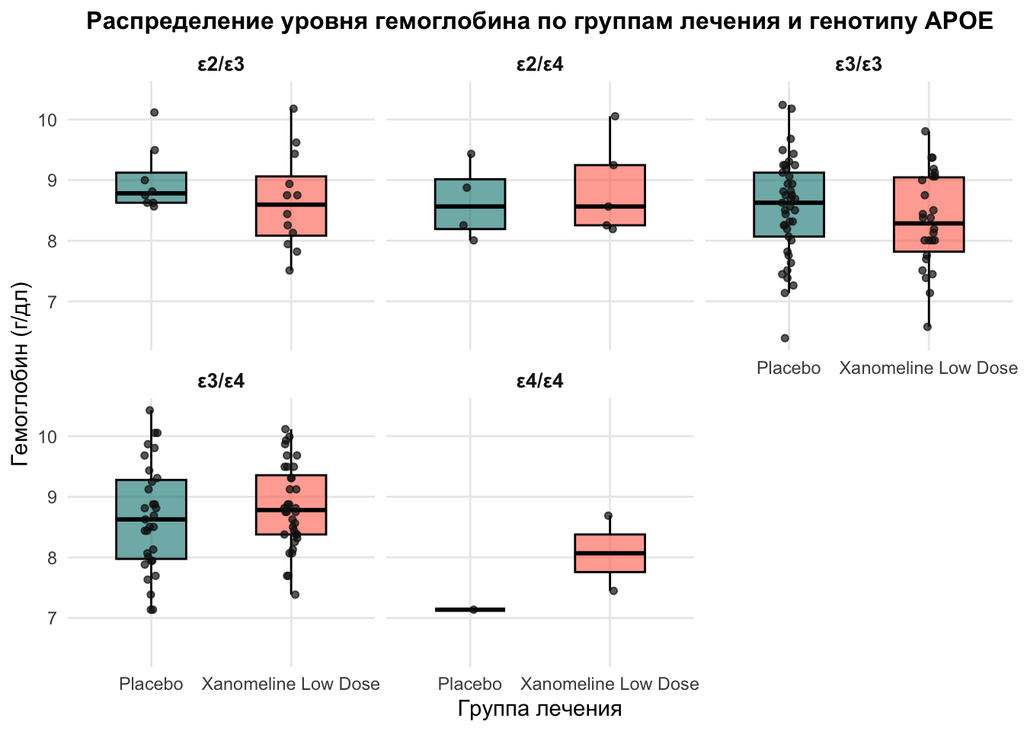

```r
# Гемоглобин: палитра Teal & Coral с контрастными черными точками
ggplot(df_merged, aes(x = ARM, y = HGB, fill = ARM)) +
  # Полупрозрачные боксплоты
  geom_boxplot(alpha = 0.6, width = 0.5, outlier.shape = NA, color = "black") +
  # Черные точки поверх коробок
  geom_point(
    position = position_jitterdodge(jitter.width = 0.15, dodge.width = 0.8),
    size = 1.3,
    alpha = 0.7,
    color = "#111111"
  ) +
  # Фасетирование по генотипам APOE
  facet_wrap(~gf_genotype_apoe) +
  # Палитра Teal & Coral
  scale_fill_manual(values = c("#008080", "#ff6f59")) +
  labs(
    title = "Распределение уровня гемоглобина по группам лечения и генотипу APOE",
    x = "Группа лечения",
    y = "Гемоглобин (г/дл)"
  ) +
  theme_minimal(base_size = 11) +
  theme(
    plot.title = element_text(face = "bold", size = 12, hjust = 0.5),
    panel.grid.minor = element_blank(),
    strip.text = element_text(face = "bold", size = 10),
    legend.position = "none"
  )
```

### Уровень тромбоцитов по группам лечения и генотипу APOE

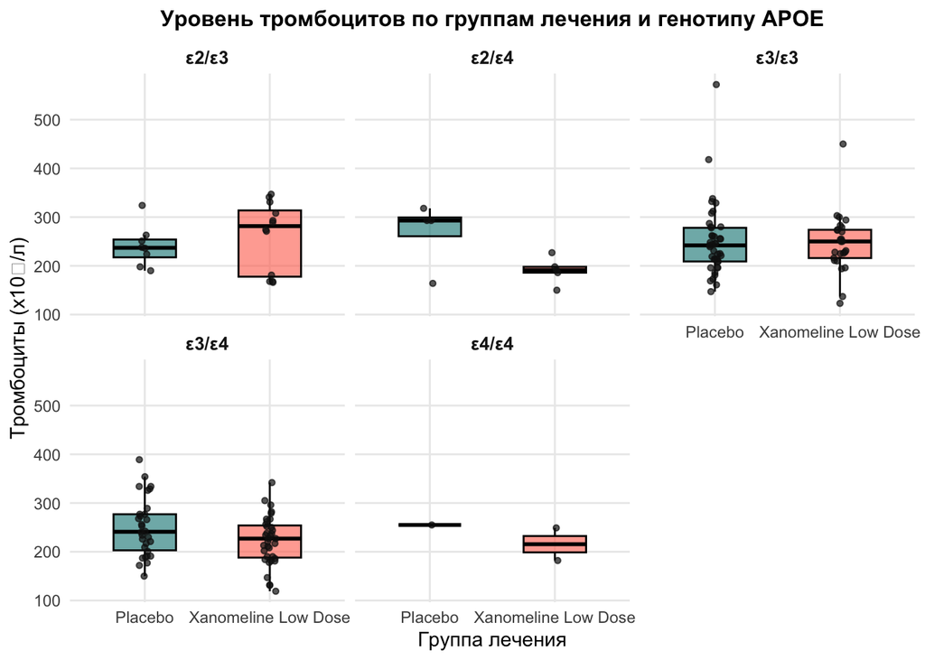

```r
# График с разделением по генотипу через фасетирование
ggplot(df_merged, aes(x = ARM, y = PLAT, fill = ARM)) +
  # Полупрозрачные боксплоты с фиксированным цветом контура
  geom_boxplot(alpha = 0.6, width = 0.5, outlier.shape = NA, color = "black") +
  # Точки контрастного черного цвета с разбросом
  geom_point(
    position = position_jitterdodge(jitter.width = 0.15, dodge.width = 0.8),
    size = 1.2,
    alpha = 0.7,
    color = "#111111"
  ) +
  facet_wrap(~gf_genotype_apoe) +
  # Палитра Teal & Coral
  scale_fill_manual(values = c("#008080", "#ff6f59")) +
  labs(
    title = "Уровень тромбоцитов по группам лечения и генотипу APOE",
    x = "Группа лечения",
    y = "Тромбоциты (x10⁹/л)"
  ) +
  theme_minimal(base_size = 11) +
  theme(
    plot.title = element_text(face = "bold", size = 12, hjust = 0.5),
    legend.position = "none",
    panel.grid.minor = element_blank(),
    strip.text = element_text(face = "bold", size = 10)
  )
```

**Комментарий к визуализации:** Стратификация уровня тромбоцитов по генотипам APOE показывает сопоставимость показателей между группами лечения в основных подгруппах($\varepsilon 3/\varepsilon 3$, $\varepsilon 3/\varepsilon 4$). В редких генотипических группах (например, $\varepsilon 4/\varepsilon 4$) наблюдается выраженное ограничение объема выборки, что требует осторожности при интерпретации различий и исключает возможность сделать статистически надежные выводы для этих подгруп.

### Сводный анализ лабораторных показателей по группам лечения и генотипу APOE

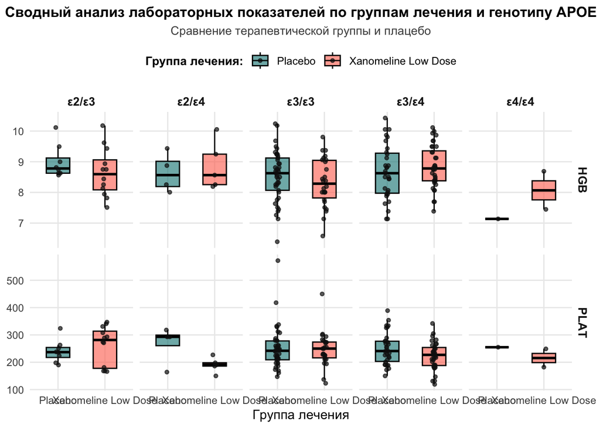

```r
df_long <- lb_wide |>
  left_join(dm, by = "ID") |>
  left_join(gf_wide, by = "ID") |>
  pivot_longer(
    cols = c(HGB, PLAT),
    names_to = "Parameter_label",
    values_to = "Value"
  )
ggplot(df_long, aes(x = ARM, y = Value, fill = ARM)) +
  # Полупрозрачные боксплоты
  geom_boxplot(alpha = 0.6, width = 0.5, outlier.shape = NA, color = "black") +
  # Контрастные черные точки
  geom_point(
    position = position_jitterdodge(jitter.width = 0.15, dodge.width = 0.8),
    size = 1.2,
    alpha = 0.7,
    color = "#111111"
  ) +
  facet_grid(Parameter_label ~ gf_genotype_apoe, scales = "free_y") +
  scale_fill_manual(
    values = c("#008080", "#ff6f59"),
    name = "Группа лечения:"
  ) +
  labs(
    title = "Сводный анализ лабораторных показателей по группам лечения и генотипу APOE",
    subtitle = "Сравнение терапевтической группы и плацебо",
    x = "Группа лечения",
    y = NULL
  ) +
  theme_minimal(base_size = 11) +
  theme(
    plot.title = element_text(face = "bold", size = 12, hjust = 0.5),
    plot.subtitle = element_text(size = 10, hjust = 0.5, color = "grey30"),
    # Переносим стандартную легенду наверх под заголовок:
    legend.position = "top",
    legend.justification = "center",
    legend.title = element_text(size = 10, face = "bold"),
    legend.text = element_text(size = 9),
    panel.grid.minor = element_blank(),
    strip.text = element_text(face = "bold", size = 10)
  )
```

### Распределение индекса массы тела (BMI) на скрининге

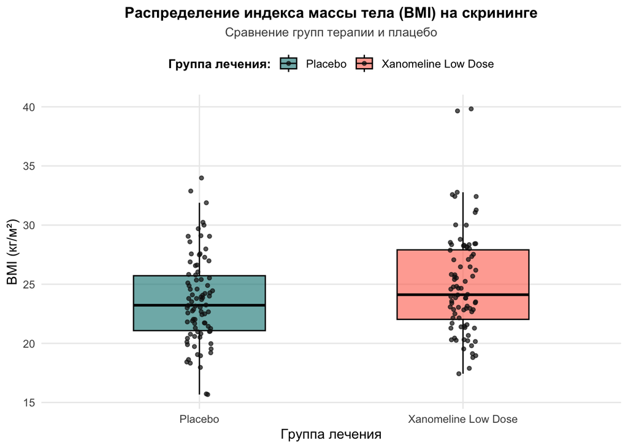

```r
library(tidyverse)
# 1. Рассчитываем BMI, подтягиваем данные и убираем NA в ARM
vs_wide_bmi <- vs_wide |>
  mutate(
    BMI = `WEIGHT_SCREENING 1` / (`HEIGHT_SCREENING 1` / 100)^2
  ) |>
  left_join(dm, by = "ID") |>
  filter(!is.na(ARM))

# 2. Строим график
ggplot(vs_wide_bmi, aes(x = ARM, y = BMI, fill = ARM)) +
  geom_boxplot(alpha = 0.6, width = 0.5, outlier.shape = NA, color = "black") +
  geom_point(
    position = position_jitterdodge(jitter.width = 0.15, dodge.width = 0.8),
    size = 1.2,
    alpha = 0.7,
    color = "#111111"
  ) +
  scale_fill_manual(
    values = c("#008080", "#ff6f59"),
    name = "Группа лечения:"
  ) +
  labs(
    title = "Распределение индекса массы тела (BMI) на скрининге",
    subtitle = "Сравнение групп терапии и плацебо",
    x = "Группа лечения",
    y = "BMI (кг/м²)"
  ) +
  theme_minimal(base_size = 11) +
  theme(
    plot.title = element_text(face = "bold", size = 12, hjust = 0.5),
    plot.subtitle = element_text(size = 10, hjust = 0.5, color = "grey30"),
    legend.position = "top",
    legend.justification = "center",
    legend.title = element_text(size = 10, face = "bold"),
    legend.text = element_text(size = 9),
    panel.grid.minor = element_blank()
  )
```

### Соотношение категорий BMI по группам лечения

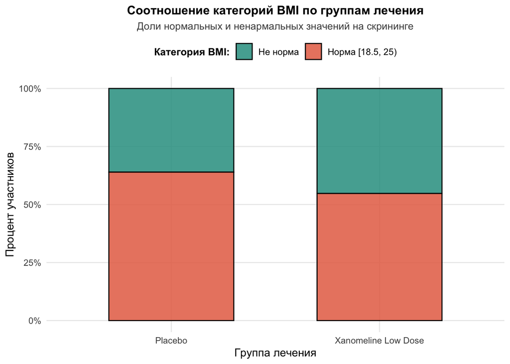

```r
library(tidyverse)

# 1. Подготавливаем данные: считаем BMI и создаем категорию нормы
vs_bmi_cat <- vs_wide |>
  mutate(
    BMI = `WEIGHT_SCREENING 1` / (`HEIGHT_SCREENING 1` / 100)^2,
    BMI_cat = if_else(BMI >= 18.5 & BMI < 25, "Норма [18.5, 25)", "Не норма")
  ) |>
  left_join(dm, by = "ID") |>
  filter(!is.na(ARM), !is.na(BMI_cat))

# 2. Строим процентную столбчатую диаграмму (barplot)
ggplot(vs_bmi_cat, aes(x = ARM, fill = BMI_cat)) +
  geom_bar(position = "fill", alpha = 0.85, color = "black", width = 0.6) +
  scale_y_continuous(labels = scales::percent) +
  scale_fill_manual(
    values = c("#2a9d8f", "#e76f51"),
    name = "Категория BMI:"
  ) +
  labs(
    title = "Соотношение категорий BMI по группам лечения",
    subtitle = "Доли нормальных и ненармальных значений на скрининге",
    x = "Группа лечения",
    y = "Процент участников"
  ) +
  theme_minimal(base_size = 11) +
  theme(
    plot.title = element_text(face = "bold", size = 12, hjust = 0.5),
    plot.subtitle = element_text(size = 10, hjust = 0.5, color = "grey30"),
    legend.position = "top",
    legend.justification = "center",
    legend.title = element_text(size = 10, face = "bold"),
    legend.text = element_text(size = 9),
    panel.grid.minor = element_blank()
  )
```

### Распределение BMI в зависимости от генотипа APOE

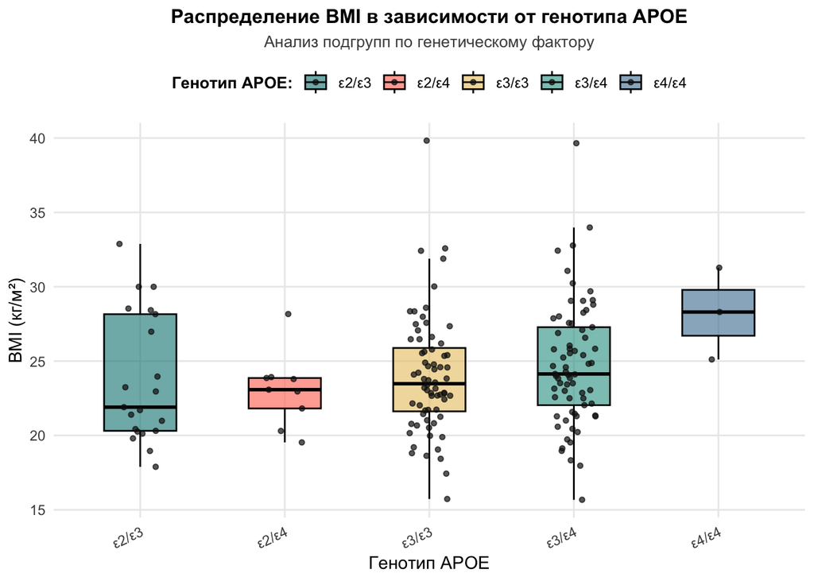

```r
library(tidyverse)

# 1. Рассчитываем BMI, подтягиваем демографию (dm) и генетику (gf_wide)
bmi_apoe_data <- vs_wide |>
  mutate(
    BMI = `WEIGHT_SCREENING 1` / (`HEIGHT_SCREENING 1` / 100)^2
  ) |>
  left_join(dm, by = "ID") |>
  left_join(gf_wide, by = "ID")

# 2. Строим график распределения BMI в зависимости от генотипа APOE
ggplot(
  bmi_apoe_data |> filter(!is.na(BMI), !is.na(gf_genotype_apoe)),
  aes(x = gf_genotype_apoe, y = BMI, fill = gf_genotype_apoe)
) +
  geom_boxplot(alpha = 0.6, width = 0.5, outlier.shape = NA, color = "black") +
  geom_point(
    position = position_jitter(width = 0.15),
    size = 1.2,
    alpha = 0.7,
    color = "#111111"
  ) +
  scale_fill_manual(
    values = c("#008080", "#ff6f59", "#e9c46a", "#2a9d8f", "#457b9d"),
    name = "Генотип APOE:"
  ) +
  labs(
    title = "Распределение BMI в зависимости от генотипа APOE",
    subtitle = "Анализ подгрупп по генетическому фактору",
    x = "Генотип APOE",
    y = "BMI (кг/м²)"
  ) +
  theme_minimal(base_size = 11) +
  theme(
    plot.title = element_text(face = "bold", size = 12, hjust = 0.5),
    plot.subtitle = element_text(size = 10, hjust = 0.5, color = "grey30"),
    legend.position = "top",
    legend.justification = "center",
    legend.title = element_text(size = 10, face = "bold"),
    legend.text = element_text(size = 9),
    panel.grid.minor = element_blank(),
    axis.text.x = element_text(angle = 25, hjust = 1) # повернут подписи, если названий много
  )
```

### Расделение BMI в зависимости от генотипа APOE и группам лечения

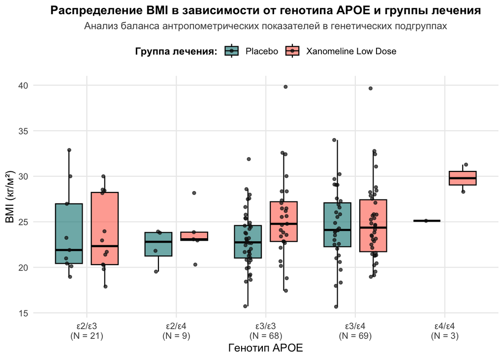

```r
library(tidyverse)

# 1. Объединяем данные, считаем BMI и убираем пропуски
bmi_apoe_data <- vs_wide |>
  mutate(
    BMI = `WEIGHT_SCREENING 1` / (`HEIGHT_SCREENING 1` / 100)^2
  ) |>
  left_join(dm, by = "ID") |>
  left_join(gf_wide, by = "ID") |>
  filter(!is.na(BMI), !is.na(gf_genotype_apoe), !is.na(ARM))

# 2. Считаем количество участников в каждой комбинации (Генотип + Группа) для подписи N
counts_lab <- bmi_apoe_data |>
  count(gf_genotype_apoe) |>
  mutate(label = str_c(gf_genotype_apoe, "\n(N = ", n, ")"))

x_labels <- setNames(counts_lab$label, counts_lab$gf_genotype_apoe)

# 3. Строим график с группировкой по ARM внутри каждого генотипа
ggplot(bmi_apoe_data, aes(x = gf_genotype_apoe, y = BMI, fill = ARM)) +
  geom_boxplot(
    alpha = 0.6,
    width = 0.6,
    outlier.shape = NA,
    color = "black",
    position = position_dodge(0.8, preserve = "single") # Добавлен preserve = "single"
  ) +
  geom_point(
    position = position_jitterdodge(jitter.width = 0.15, dodge.width = 0.8),
    size = 1.2,
    alpha = 0.7,
    color = "#111111"
  ) +
  scale_x_discrete(labels = x_labels) +
  scale_fill_manual(
    values = c("#008080", "#ff6f59"),
    name = "Группа лечения:"
  ) +
  labs(
    title = "Распределение BMI в зависимости от генотипа APOE и группы лечения",
    subtitle = "Анализ баланса антропометрических показателей в генетических подгруппах",
    x = "Генотип APOE",
    y = "BMI (кг/м²)"
  ) +
  theme_minimal(base_size = 11) +
  theme(
    plot.title = element_text(face = "bold", size = 12, hjust = 0.5),
    plot.subtitle = element_text(size = 10, hjust = 0.5, color = "grey30"),
    legend.position = "top",
    legend.justification = "center",
    legend.title = element_text(size = 10, face = "bold"),
    legend.text = element_text(size = 9),
    panel.grid.minor = element_blank(),
    axis.text.x = element_text(size = 9)
  )
```

### Распределение генотипов APOE по группам лечения

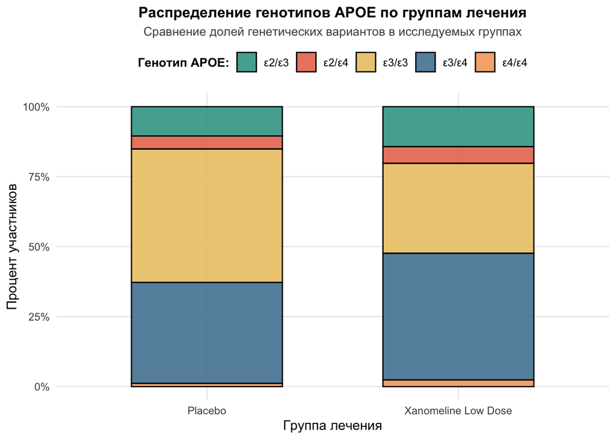

```r
library(tidyverse)

# 1. Объединяем данные демографии и генетики
apoe_arm_data <- dm |>
  left_join(gf_wide, by = "ID") |>
  filter(!is.na(ARM), !is.na(gf_genotype_apoe))

# 2. Строим процентную диаграмму распределения генотипов по группам
ggplot(apoe_arm_data, aes(x = ARM, fill = gf_genotype_apoe)) +
  geom_bar(position = "fill", alpha = 0.85, color = "black", width = 0.6) +
  scale_y_continuous(labels = scales::percent) +
  scale_fill_manual(
    values = c("#2a9d8f", "#e76f51", "#e9c46a", "#457b9d", "#f4a261"),
    name = "Генотип APOE:"
  ) +
  labs(
    title = "Распределение генотипов APOE по группам лечения",
    subtitle = "Сравнение долей генетических вариантов в исследуемых группах",
    x = "Группа лечения",
    y = "Процент участников"
  ) +
  theme_minimal(base_size = 11) +
  theme(
    plot.title = element_text(face = "bold", size = 12, hjust = 0.5),
    plot.subtitle = element_text(size = 10, hjust = 0.5, color = "grey30"),
    legend.position = "top",
    legend.justification = "center",
    legend.title = element_text(size = 10, face = "bold"),
    legend.text = element_text(size = 9),
    panel.grid.minor = element_blank()
  )
```

### 4.3. Таблицы

```r
tables_lab <- df_merged |>
  select(ARM, HGB, PLAT) |>
  drop_na() |>
  tbl_summary(
    by = ARM,
    label = list(
      HGB ~ "Гемоглобин, ммоль/л",
      PLAT ~ "Тромбоциты, ×10⁹/л"
    )
  ) |>
  modify_header(
    label ~ "Показатель",
    stat_1 ~ "Плацебо",
    stat_2 ~ "Низкие дозы Ксаномелина"
  ) |>
  modify_caption("Лабораторные показатели по группам лечения") |>
  modify_footnote(
    all_stat_cols() ~ "Данные представлены как медиана (Q1; Q3)"
  )

tables_lab
```

Лабораторные показатели по группам лечения

| Показатель | Плацебо<sup>1</sup> | Низкие дозы Ксаномелина<sup>1</sup> |
| --- | --- | --- |
| Гемоглобин, ммоль/л | 8.63 (8.04, 9.22) | 8.56 (8.13, 9.12) |
| Тромбоциты, ×10⁹/л | 242 (209, 279) | 228 (190, 273) |

<sup>1</sup> Данные представлены как медиана (Q1; Q3)

```r
tables_vit <- df_merged |>
  select(ARM, `HEIGHT_SCREENING 1`, `WEIGHT_SCREENING 1`, `WEIGHT_WEEK 4`) |>
  drop_na() |>
  tbl_summary(
    by = ARM,
    statistic = all_continuous() ~ "{mean} ({sd})",
    label = list(
      `HEIGHT_SCREENING 1` ~ "Рост, см",
      `WEIGHT_SCREENING 1` ~ "Вес при скрининге, кг",
      `WEIGHT_WEEK 4` ~ "Вес через 4 недели, кг"
    )
  ) |>
  modify_header(
    label ~ "Показатель",
    stat_1 ~ "Плацебо",
    stat_2 ~ "Низкие дозы Ксаномелина"
  ) |>
  modify_caption("Рост и вес по группам лечения") |>
  modify_footnote(
    all_stat_cols() ~ "Данные представлены как среднее (стандартное отклонение)"
  )

tables_vit
```

Рост и вес по группам лечения

| Показатель | Плацебо<sup>1</sup> | Низкие дозы Ксаномелина<sup>1</sup> |
| --- | --- | --- |
| Рост, см | 163 (12) | 163 (10) |
| Вес при скрининге, кг | 63 (13) | 67 (14) |
| Вес через 4 недели, кг | 63 (13) | 67 (14) |

<sup>1</sup> Данные представлены как среднее (стандартное отклонение)

### 4.4. Заполнение пропущенных значений

Создайте и загрузите на GitHub экспериментальную ветку `imputation`. В этой ветке перед разделом 3 заполните пропущенные значения количественных показателей, используемых в анализе, средним значением показателя в группе по полу и возрасту. Используйте возрастные группы 50-59, 60-69, 70-79 и 80-89 лет. В дальнейшем анализе используйте датафрейм после заполнения пропусков.

### 4.5. Оформите README.md

Замените содержимое README.md кратким описание команды, кто какие пункты выполнил